# Risk Factor Analysis

## Outcome Variable

**Outcome Variable:** ever_sstunted

## Predictor Variables

**Intervention Variable:** parity

**Adjustment Set:**

- arm
- W_mage
- meducyrs
- feducyrs
- hhwealth_quart
- W_mhtcm
- vagbrth
- W_nrooms
- impsan
- delta_W_mage
- delta_meducyrs
- delta_feducyrs
- delta_hhwealth_quart
- delta_W_mhtcm
- delta_vagbrth
- delta_W_nrooms
- delta_impsan

## Stratifying Variables

The analysis was stratified on these variable(s):

- agecat
- studyid
- country

## Data Summary

| agecat | studyid | country | parity | ever_sstunted | n_cell | n |
| --- | --- | --- | --- | --- | --- | --- |
| 0-24 months | ki1000304b-SAS-CompFeed | INDIA | 1 | 0 | 310 | 1533 |
| 0-24 months | ki1000304b-SAS-CompFeed | INDIA | 1 | 1 | 142 | 1533 |
| 0-24 months | ki1000304b-SAS-CompFeed | INDIA | 2 | 0 | 261 | 1533 |
| 0-24 months | ki1000304b-SAS-CompFeed | INDIA | 2 | 1 | 99 | 1533 |
| 0-24 months | ki1000304b-SAS-CompFeed | INDIA | 3+ | 0 | 455 | 1533 |
| 0-24 months | ki1000304b-SAS-CompFeed | INDIA | 3+ | 1 | 266 | 1533 |
| 0-24 months | ki1000304b-SAS-FoodSuppl | INDIA | 1 | 0 | 46 | 397 |
| 0-24 months | ki1000304b-SAS-FoodSuppl | INDIA | 1 | 1 | 31 | 397 |
| 0-24 months | ki1000304b-SAS-FoodSuppl | INDIA | 2 | 0 | 51 | 397 |
| 0-24 months | ki1000304b-SAS-FoodSuppl | INDIA | 2 | 1 | 41 | 397 |
| 0-24 months | ki1000304b-SAS-FoodSuppl | INDIA | 3+ | 0 | 103 | 397 |
| 0-24 months | ki1000304b-SAS-FoodSuppl | INDIA | 3+ | 1 | 125 | 397 |
| 0-24 months | ki1017093b-PROVIDE | BANGLADESH | 1 | 0 | 227 | 700 |
| 0-24 months | ki1017093b-PROVIDE | BANGLADESH | 1 | 1 | 44 | 700 |
| 0-24 months | ki1017093b-PROVIDE | BANGLADESH | 2 | 0 | 215 | 700 |
| 0-24 months | ki1017093b-PROVIDE | BANGLADESH | 2 | 1 | 29 | 700 |
| 0-24 months | ki1017093b-PROVIDE | BANGLADESH | 3+ | 0 | 164 | 700 |
| 0-24 months | ki1017093b-PROVIDE | BANGLADESH | 3+ | 1 | 21 | 700 |
| 0-24 months | ki1066203-TanzaniaChild2 | TANZANIA, UNITED REPUBLIC OF | 1 | 0 | 750 | 2357 |
| 0-24 months | ki1066203-TanzaniaChild2 | TANZANIA, UNITED REPUBLIC OF | 1 | 1 | 71 | 2357 |
| 0-24 months | ki1066203-TanzaniaChild2 | TANZANIA, UNITED REPUBLIC OF | 2 | 0 | 688 | 2357 |
| 0-24 months | ki1066203-TanzaniaChild2 | TANZANIA, UNITED REPUBLIC OF | 2 | 1 | 83 | 2357 |
| 0-24 months | ki1066203-TanzaniaChild2 | TANZANIA, UNITED REPUBLIC OF | 3+ | 0 | 685 | 2357 |
| 0-24 months | ki1066203-TanzaniaChild2 | TANZANIA, UNITED REPUBLIC OF | 3+ | 1 | 80 | 2357 |
| 0-24 months | ki1101329-Keneba | GAMBIA | 1 | 0 | 182 | 1990 |
| 0-24 months | ki1101329-Keneba | GAMBIA | 1 | 1 | 59 | 1990 |
| 0-24 months | ki1101329-Keneba | GAMBIA | 2 | 0 | 173 | 1990 |
| 0-24 months | ki1101329-Keneba | GAMBIA | 2 | 1 | 41 | 1990 |
| 0-24 months | ki1101329-Keneba | GAMBIA | 3+ | 0 | 1158 | 1990 |
| 0-24 months | ki1101329-Keneba | GAMBIA | 3+ | 1 | 377 | 1990 |

[output cut: 102 more lines]

The following strata were considered:

- agecat: 0-24 months, studyid: ki1000304b-SAS-CompFeed, country: INDIA
- agecat: 0-24 months, studyid: ki1000304b-SAS-FoodSuppl, country: INDIA
- agecat: 0-24 months, studyid: ki1017093b-PROVIDE, country: BANGLADESH
- agecat: 0-24 months, studyid: ki1066203-TanzaniaChild2, country: TANZANIA, UNITED REPUBLIC OF
- agecat: 0-24 months, studyid: ki1101329-Keneba, country: GAMBIA
- agecat: 0-24 months, studyid: ki1113344-GMS-Nepal, country: NEPAL
- agecat: 0-24 months, studyid: ki1126311-ZVITAMBO, country: ZIMBABWE
- agecat: 0-24 months, studyid: ki1135781-COHORTS, country: GUATEMALA
- agecat: 0-24 months, studyid: ki1135781-COHORTS, country: INDIA
- agecat: 0-24 months, studyid: ki1135781-COHORTS, country: PHILIPPINES
- agecat: 0-24 months, studyid: kiGH5241-JiVitA-3, country: BANGLADESH
- agecat: 0-6 months, studyid: ki1000304b-SAS-CompFeed, country: INDIA
- agecat: 0-6 months, studyid: ki1000304b-SAS-FoodSuppl, country: INDIA
- agecat: 0-6 months, studyid: ki1017093b-PROVIDE, country: BANGLADESH
- agecat: 0-6 months, studyid: ki1066203-TanzaniaChild2, country: TANZANIA, UNITED REPUBLIC OF
- agecat: 0-6 months, studyid: ki1101329-Keneba, country: GAMBIA
- agecat: 0-6 months, studyid: ki1113344-GMS-Nepal, country: NEPAL
- agecat: 0-6 months, studyid: ki1126311-ZVITAMBO, country: ZIMBABWE
- agecat: 0-6 months, studyid: ki1135781-COHORTS, country: GUATEMALA
- agecat: 0-6 months, studyid: ki1135781-COHORTS, country: INDIA
- agecat: 0-6 months, studyid: ki1135781-COHORTS, country: PHILIPPINES
- agecat: 0-6 months, studyid: kiGH5241-JiVitA-3, country: BANGLADESH

## Methods Detail

We’re interested in the causal parameters $E[Y_a]$ for all values of $a \in \mathcal{A}$. These parameters represent the mean outcome if, possibly contrary to fact, we intervened to set all units to have $A=a$. Under the randomization and positivity assumptions, these are identified by the statistical parameters $\psi_a=E_W[E_{Y|A,W}(Y|A=a,W)]$. In addition, we’re interested in the mean of $Y$, $E[Y]$ under no intervention (the observed mean). We will estimate these parameters by using SuperLearner to fit the relevant likelihood factors – $E_{Y|A,W}(Y|A=a,W)$ and $p(A=a|W)$, and then updating our likelihood fit using a joint TMLE.

For unadjusted analyses ($W=\{\}$), initial likelihoods were estimated using Lrnr_glm to estimate the simple $E(Y|A)$ and Lrnr_mean to estimate $p(A)$. For adjusted analyses, a small library containing Lrnr_glmnet, Lrnr_xgboost, and Lrnr_mean was used.

Having estimated these parameters, we will then use the delta method to estimate relative risks and attributable risks relative to a prespecified baseline level of $A$.

# Results Detail

## Results Plots

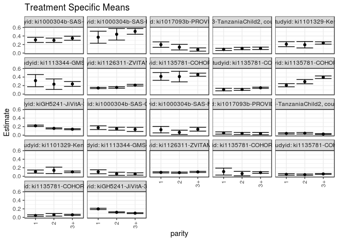

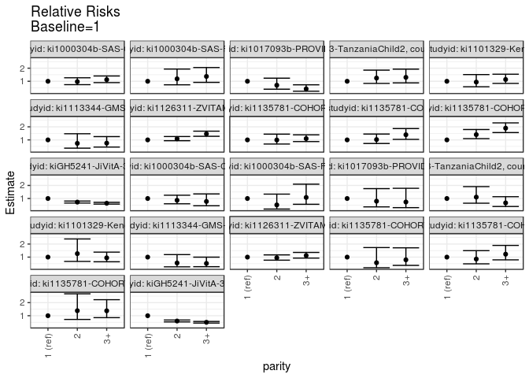

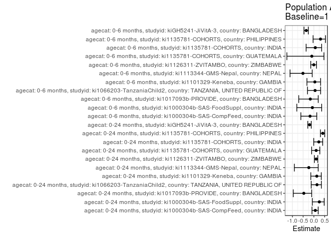

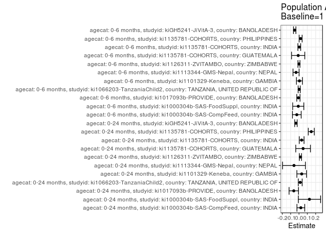

## Results Table

### Parameter: TSM

| agecat | studyid | country | intervention_level | baseline_level | estimate | ci_lower | ci_upper |
| --- | --- | --- | --- | --- | --- | --- | --- |
| 0-24 months | ki1000304b-SAS-CompFeed | INDIA | 1 | NA | 0.3085955 | 0.2482601 | 0.3689309 |
| 0-24 months | ki1000304b-SAS-CompFeed | INDIA | 2 | NA | 0.2989675 | 0.2477634 | 0.3501715 |
| 0-24 months | ki1000304b-SAS-CompFeed | INDIA | 3+ | NA | 0.3467026 | 0.2991491 | 0.3942561 |
| 0-24 months | ki1000304b-SAS-FoodSuppl | INDIA | 1 | NA | 0.3708516 | 0.2297093 | 0.5119939 |
| 0-24 months | ki1000304b-SAS-FoodSuppl | INDIA | 2 | NA | 0.4401910 | 0.3042927 | 0.5760893 |
| 0-24 months | ki1000304b-SAS-FoodSuppl | INDIA | 3+ | NA | 0.5081503 | 0.4404463 | 0.5758543 |
| 0-24 months | ki1017093b-PROVIDE | BANGLADESH | 1 | NA | 0.1973135 | 0.1333041 | 0.2613228 |
| 0-24 months | ki1017093b-PROVIDE | BANGLADESH | 2 | NA | 0.1376021 | 0.0721640 | 0.2030402 |
| 0-24 months | ki1017093b-PROVIDE | BANGLADESH | 3+ | NA | 0.0823849 | 0.0444575 | 0.1203124 |
| 0-24 months | ki1066203-TanzaniaChild2 | TANZANIA, UNITED REPUBLIC OF | 1 | NA | 0.0849855 | 0.0595150 | 0.1104559 |
| 0-24 months | ki1066203-TanzaniaChild2 | TANZANIA, UNITED REPUBLIC OF | 2 | NA | 0.1058568 | 0.0784249 | 0.1332887 |
| 0-24 months | ki1066203-TanzaniaChild2 | TANZANIA, UNITED REPUBLIC OF | 3+ | NA | 0.1103881 | 0.0820840 | 0.1386922 |
| 0-24 months | ki1101329-Keneba | GAMBIA | 1 | NA | 0.2075052 | 0.1489940 | 0.2660163 |
| 0-24 months | ki1101329-Keneba | GAMBIA | 2 | NA | 0.1944437 | 0.1193700 | 0.2695174 |
| 0-24 months | ki1101329-Keneba | GAMBIA | 3+ | NA | 0.2358746 | 0.2088617 | 0.2628876 |
| 0-24 months | ki1113344-GMS-Nepal | NEPAL | 1 | NA | 0.3161828 | 0.1737337 | 0.4586320 |
| 0-24 months | ki1113344-GMS-Nepal | NEPAL | 2 | NA | 0.2323764 | 0.1098994 | 0.3548535 |
| 0-24 months | ki1113344-GMS-Nepal | NEPAL | 3+ | NA | 0.2373955 | 0.1801080 | 0.2946829 |
| 0-24 months | ki1126311-ZVITAMBO | ZIMBABWE | 1 | NA | 0.1437267 | 0.1298857 | 0.1575677 |
| 0-24 months | ki1126311-ZVITAMBO | ZIMBABWE | 2 | NA | 0.1561222 | 0.1388173 | 0.1734271 |
| 0-24 months | ki1126311-ZVITAMBO | ZIMBABWE | 3+ | NA | 0.2094893 | 0.1898897 | 0.2290888 |
| 0-24 months | ki1135781-COHORTS | GUATEMALA | 1 | NA | 0.4146870 | 0.3235173 | 0.5058568 |
| 0-24 months | ki1135781-COHORTS | GUATEMALA | 2 | NA | 0.4111780 | 0.2872820 | 0.5350739 |
| 0-24 months | ki1135781-COHORTS | GUATEMALA | 3+ | NA | 0.4559882 | 0.4192883 | 0.4926880 |
| 0-24 months | ki1135781-COHORTS | INDIA | 1 | NA | 0.1067676 | 0.0773031 | 0.1362320 |
| 0-24 months | ki1135781-COHORTS | INDIA | 2 | NA | 0.1093411 | 0.0864896 | 0.1321926 |
| 0-24 months | ki1135781-COHORTS | INDIA | 3+ | NA | 0.1486374 | 0.1342627 | 0.1630122 |
| 0-24 months | ki1135781-COHORTS | PHILIPPINES | 1 | NA | 0.2086165 | 0.1712206 | 0.2460123 |
| 0-24 months | ki1135781-COHORTS | PHILIPPINES | 2 | NA | 0.2923753 | 0.2422929 | 0.3424576 |
| 0-24 months | ki1135781-COHORTS | PHILIPPINES | 3+ | NA | 0.3951297 | 0.3647013 | 0.4255580 |
| 0-24 months | kiGH5241-JiVitA-3 | BANGLADESH | 1 | NA | 0.2206697 | 0.2047838 | 0.2365557 |
| 0-24 months | kiGH5241-JiVitA-3 | BANGLADESH | 2 | NA | 0.1597394 | 0.1474050 | 0.1720737 |
| 0-24 months | kiGH5241-JiVitA-3 | BANGLADESH | 3+ | NA | 0.1403551 | 0.1288882 | 0.1518220 |
| 0-6 months | ki1000304b-SAS-CompFeed | INDIA | 1 | NA | 0.1764267 | 0.1322408 | 0.2206126 |
| 0-6 months | ki1000304b-SAS-CompFeed | INDIA | 2 | NA | 0.1523398 | 0.1179705 | 0.1867090 |
| 0-6 months | ki1000304b-SAS-CompFeed | INDIA | 3+ | NA | 0.1364523 | 0.0877959 | 0.1851087 |
| 0-6 months | ki1000304b-SAS-FoodSuppl | INDIA | 1 | NA | 0.1298701 | 0.0546908 | 0.2050495 |
| 0-6 months | ki1000304b-SAS-FoodSuppl | INDIA | 2 | NA | 0.0659341 | 0.0148812 | 0.1169869 |
| 0-6 months | ki1000304b-SAS-FoodSuppl | INDIA | 3+ | NA | 0.1403509 | 0.0952071 | 0.1854947 |
| 0-6 months | ki1017093b-PROVIDE | BANGLADESH | 1 | NA | 0.0516605 | 0.0252890 | 0.0780320 |
| 0-6 months | ki1017093b-PROVIDE | BANGLADESH | 2 | NA | 0.0409836 | 0.0160904 | 0.0658769 |
| 0-6 months | ki1017093b-PROVIDE | BANGLADESH | 3+ | NA | 0.0378378 | 0.0103234 | 0.0653522 |
| 0-6 months | ki1066203-TanzaniaChild2 | TANZANIA, UNITED REPUBLIC OF | 1 | NA | 0.0408750 | 0.0257427 | 0.0560074 |
| 0-6 months | ki1066203-TanzaniaChild2 | TANZANIA, UNITED REPUBLIC OF | 2 | NA | 0.0451619 | 0.0269834 | 0.0633404 |
| 0-6 months | ki1066203-TanzaniaChild2 | TANZANIA, UNITED REPUBLIC OF | 3+ | NA | 0.0271322 | 0.0165184 | 0.0377460 |
| 0-6 months | ki1101329-Keneba | GAMBIA | 1 | NA | 0.1102591 | 0.0732714 | 0.1472469 |
| 0-6 months | ki1101329-Keneba | GAMBIA | 2 | NA | 0.1394874 | 0.0641525 | 0.2148222 |
| 0-6 months | ki1101329-Keneba | GAMBIA | 3+ | NA | 0.1039826 | 0.0849136 | 0.1230517 |
| 0-6 months | ki1113344-GMS-Nepal | NEPAL | 1 | NA | 0.1052632 | 0.0592272 | 0.1512991 |
| 0-6 months | ki1113344-GMS-Nepal | NEPAL | 2 | NA | 0.0580645 | 0.0212169 | 0.0949121 |
| 0-6 months | ki1113344-GMS-Nepal | NEPAL | 3+ | NA | 0.0543478 | 0.0275801 | 0.0811155 |
| 0-6 months | ki1126311-ZVITAMBO | ZIMBABWE | 1 | NA | 0.0912487 | 0.0783076 | 0.1041898 |
| 0-6 months | ki1126311-ZVITAMBO | ZIMBABWE | 2 | NA | 0.0863576 | 0.0727378 | 0.0999775 |
| 0-6 months | ki1126311-ZVITAMBO | ZIMBABWE | 3+ | NA | 0.1021273 | 0.0886239 | 0.1156306 |
| 0-6 months | ki1135781-COHORTS | GUATEMALA | 1 | NA | 0.1106055 | 0.0292219 | 0.1919892 |
| 0-6 months | ki1135781-COHORTS | GUATEMALA | 2 | NA | 0.0631068 | 0.0107362 | 0.1154773 |
| 0-6 months | ki1135781-COHORTS | GUATEMALA | 3+ | NA | 0.0876118 | 0.0678007 | 0.1074228 |
| 0-6 months | ki1135781-COHORTS | INDIA | 1 | NA | 0.0449259 | 0.0271168 | 0.0627349 |
| 0-6 months | ki1135781-COHORTS | INDIA | 2 | NA | 0.0382306 | 0.0229710 | 0.0534902 |
| 0-6 months | ki1135781-COHORTS | INDIA | 3+ | NA | 0.0549843 | 0.0449085 | 0.0650601 |
| 0-6 months | ki1135781-COHORTS | PHILIPPINES | 1 | NA | 0.0432260 | 0.0247698 | 0.0616823 |
| 0-6 months | ki1135781-COHORTS | PHILIPPINES | 2 | NA | 0.0598283 | 0.0296978 | 0.0899588 |
| 0-6 months | ki1135781-COHORTS | PHILIPPINES | 3+ | NA | 0.0595102 | 0.0463438 | 0.0726766 |
| 0-6 months | kiGH5241-JiVitA-3 | BANGLADESH | 1 | NA | 0.1987876 | 0.1828916 | 0.2146837 |
| 0-6 months | kiGH5241-JiVitA-3 | BANGLADESH | 2 | NA | 0.1183614 | 0.1071171 | 0.1296057 |
| 0-6 months | kiGH5241-JiVitA-3 | BANGLADESH | 3+ | NA | 0.0988219 | 0.0887270 | 0.1089168 |

### Parameter: E(Y)

| agecat | studyid | country | intervention_level | baseline_level | estimate | ci_lower | ci_upper |
| --- | --- | --- | --- | --- | --- | --- | --- |
| 0-24 months | ki1000304b-SAS-CompFeed | INDIA | NA | NA | 0.3307241 | 0.3024794 | 0.3589688 |
| 0-24 months | ki1000304b-SAS-FoodSuppl | INDIA | NA | NA | 0.4962217 | 0.4469771 | 0.5454662 |
| 0-24 months | ki1017093b-PROVIDE | BANGLADESH | NA | NA | 0.1342857 | 0.1090095 | 0.1595619 |
| 0-24 months | ki1066203-TanzaniaChild2 | TANZANIA, UNITED REPUBLIC OF | NA | NA | 0.0992787 | 0.0872038 | 0.1113537 |
| 0-24 months | ki1101329-Keneba | GAMBIA | NA | NA | 0.2396985 | 0.2209375 | 0.2584595 |
| 0-24 months | ki1113344-GMS-Nepal | NEPAL | NA | NA | 0.2558140 | 0.2209310 | 0.2906969 |
| 0-24 months | ki1126311-ZVITAMBO | ZIMBABWE | NA | NA | 0.1610290 | 0.1549559 | 0.1671021 |
| 0-24 months | ki1135781-COHORTS | GUATEMALA | NA | NA | 0.4639706 | 0.4374564 | 0.4904847 |
| 0-24 months | ki1135781-COHORTS | INDIA | NA | NA | 0.1384449 | 0.1284958 | 0.1483940 |
| 0-24 months | ki1135781-COHORTS | PHILIPPINES | NA | NA | 0.3561151 | 0.3391405 | 0.3730897 |
| 0-24 months | kiGH5241-JiVitA-3 | BANGLADESH | NA | NA | 0.1837860 | 0.1782094 | 0.1893625 |
| 0-6 months | ki1000304b-SAS-CompFeed | INDIA | NA | NA | 0.1496732 | 0.1307571 | 0.1685893 |
| 0-6 months | ki1000304b-SAS-FoodSuppl | INDIA | NA | NA | 0.1212121 | 0.0890263 | 0.1533979 |
| 0-6 months | ki1017093b-PROVIDE | BANGLADESH | NA | NA | 0.0442857 | 0.0290345 | 0.0595370 |
| 0-6 months | ki1066203-TanzaniaChild2 | TANZANIA, UNITED REPUBLIC OF | NA | NA | 0.0432754 | 0.0350591 | 0.0514916 |
| 0-6 months | ki1101329-Keneba | GAMBIA | NA | NA | 0.1154884 | 0.1009322 | 0.1300446 |
| 0-6 months | ki1113344-GMS-Nepal | NEPAL | NA | NA | 0.0697674 | 0.0494002 | 0.0901347 |
| 0-6 months | ki1126311-ZVITAMBO | ZIMBABWE | NA | NA | 0.0908897 | 0.0861364 | 0.0956429 |
| 0-6 months | ki1135781-COHORTS | GUATEMALA | NA | NA | 0.1008249 | 0.0829501 | 0.1186997 |
| 0-6 months | ki1135781-COHORTS | INDIA | NA | NA | 0.0480662 | 0.0417969 | 0.0543355 |
| 0-6 months | ki1135781-COHORTS | PHILIPPINES | NA | NA | 0.0624591 | 0.0538810 | 0.0710373 |
| 0-6 months | kiGH5241-JiVitA-3 | BANGLADESH | NA | NA | 0.1466937 | 0.1416785 | 0.1517088 |

### Parameter: RR

| agecat | studyid | country | intervention_level | baseline_level | estimate | ci_lower | ci_upper |
| --- | --- | --- | --- | --- | --- | --- | --- |
| 0-24 months | ki1000304b-SAS-CompFeed | INDIA | 1 | 1 | 1.0000000 | 1.0000000 | 1.0000000 |
| 0-24 months | ki1000304b-SAS-CompFeed | INDIA | 2 | 1 | 0.9688005 | 0.7407386 | 1.2670790 |
| 0-24 months | ki1000304b-SAS-CompFeed | INDIA | 3+ | 1 | 1.1234855 | 0.8982213 | 1.4052435 |
| 0-24 months | ki1000304b-SAS-FoodSuppl | INDIA | 1 | 1 | 1.0000000 | 1.0000000 | 1.0000000 |
| 0-24 months | ki1000304b-SAS-FoodSuppl | INDIA | 2 | 1 | 1.1869734 | 0.7285876 | 1.9337495 |
| 0-24 months | ki1000304b-SAS-FoodSuppl | INDIA | 3+ | 1 | 1.3702254 | 0.9159027 | 2.0499094 |
| 0-24 months | ki1017093b-PROVIDE | BANGLADESH | 1 | 1 | 1.0000000 | 1.0000000 | 1.0000000 |
| 0-24 months | ki1017093b-PROVIDE | BANGLADESH | 2 | 1 | 0.6973781 | 0.3931447 | 1.2370412 |
| 0-24 months | ki1017093b-PROVIDE | BANGLADESH | 3+ | 1 | 0.4175333 | 0.2387739 | 0.7301221 |
| 0-24 months | ki1066203-TanzaniaChild2 | TANZANIA, UNITED REPUBLIC OF | 1 | 1 | 1.0000000 | 1.0000000 | 1.0000000 |
| 0-24 months | ki1066203-TanzaniaChild2 | TANZANIA, UNITED REPUBLIC OF | 2 | 1 | 1.2455875 | 0.8383267 | 1.8506963 |
| 0-24 months | ki1066203-TanzaniaChild2 | TANZANIA, UNITED REPUBLIC OF | 3+ | 1 | 1.2989055 | 0.8755379 | 1.9269931 |
| 0-24 months | ki1101329-Keneba | GAMBIA | 1 | 1 | 1.0000000 | 1.0000000 | 1.0000000 |
| 0-24 months | ki1101329-Keneba | GAMBIA | 2 | 1 | 0.9370548 | 0.5808784 | 1.5116274 |
| 0-24 months | ki1101329-Keneba | GAMBIA | 3+ | 1 | 1.1367170 | 0.8384072 | 1.5411670 |
| 0-24 months | ki1113344-GMS-Nepal | NEPAL | 1 | 1 | 1.0000000 | 1.0000000 | 1.0000000 |
| 0-24 months | ki1113344-GMS-Nepal | NEPAL | 2 | 1 | 0.7349433 | 0.3672205 | 1.4708917 |
| 0-24 months | ki1113344-GMS-Nepal | NEPAL | 3+ | 1 | 0.7508170 | 0.4505125 | 1.2512997 |
| 0-24 months | ki1126311-ZVITAMBO | ZIMBABWE | 1 | 1 | 1.0000000 | 1.0000000 | 1.0000000 |
| 0-24 months | ki1126311-ZVITAMBO | ZIMBABWE | 2 | 1 | 1.0862438 | 0.9380202 | 1.2578894 |
| 0-24 months | ki1126311-ZVITAMBO | ZIMBABWE | 3+ | 1 | 1.4575529 | 1.2745493 | 1.6668329 |
| 0-24 months | ki1135781-COHORTS | GUATEMALA | 1 | 1 | 1.0000000 | 1.0000000 | 1.0000000 |
| 0-24 months | ki1135781-COHORTS | GUATEMALA | 2 | 1 | 0.9915381 | 0.6833506 | 1.4387166 |
| 0-24 months | ki1135781-COHORTS | GUATEMALA | 3+ | 1 | 1.0995960 | 0.8712447 | 1.3877976 |
| 0-24 months | ki1135781-COHORTS | INDIA | 1 | 1 | 1.0000000 | 1.0000000 | 1.0000000 |
| 0-24 months | ki1135781-COHORTS | INDIA | 2 | 1 | 1.0241046 | 0.7246687 | 1.4472685 |
| 0-24 months | ki1135781-COHORTS | INDIA | 3+ | 1 | 1.3921592 | 1.0394373 | 1.8645733 |
| 0-24 months | ki1135781-COHORTS | PHILIPPINES | 1 | 1 | 1.0000000 | 1.0000000 | 1.0000000 |
| 0-24 months | ki1135781-COHORTS | PHILIPPINES | 2 | 1 | 1.4014965 | 1.0953311 | 1.7932407 |
| 0-24 months | ki1135781-COHORTS | PHILIPPINES | 3+ | 1 | 1.8940482 | 1.5592984 | 2.3006621 |
| 0-24 months | kiGH5241-JiVitA-3 | BANGLADESH | 1 | 1 | 1.0000000 | 1.0000000 | 1.0000000 |
| 0-24 months | kiGH5241-JiVitA-3 | BANGLADESH | 2 | 1 | 0.7238843 | 0.6518371 | 0.8038949 |
| 0-24 months | kiGH5241-JiVitA-3 | BANGLADESH | 3+ | 1 | 0.6360415 | 0.5723871 | 0.7067748 |
| 0-6 months | ki1000304b-SAS-CompFeed | INDIA | 1 | 1 | 1.0000000 | 1.0000000 | 1.0000000 |
| 0-6 months | ki1000304b-SAS-CompFeed | INDIA | 2 | 1 | 0.8634735 | 0.5957136 | 1.2515854 |
| 0-6 months | ki1000304b-SAS-CompFeed | INDIA | 3+ | 1 | 0.7734223 | 0.4436538 | 1.3483081 |
| 0-6 months | ki1000304b-SAS-FoodSuppl | INDIA | 1 | 1 | 1.0000000 | 1.0000000 | 1.0000000 |
| 0-6 months | ki1000304b-SAS-FoodSuppl | INDIA | 2 | 1 | 0.5076923 | 0.1930800 | 1.3349467 |
| 0-6 months | ki1000304b-SAS-FoodSuppl | INDIA | 3+ | 1 | 1.0807018 | 0.5573126 | 2.0956217 |
| 0-6 months | ki1017093b-PROVIDE | BANGLADESH | 1 | 1 | 1.0000000 | 1.0000000 | 1.0000000 |
| 0-6 months | ki1017093b-PROVIDE | BANGLADESH | 2 | 1 | 0.7933255 | 0.3588172 | 1.7540002 |
| 0-6 months | ki1017093b-PROVIDE | BANGLADESH | 3+ | 1 | 0.7324324 | 0.3012417 | 1.7808198 |
| 0-6 months | ki1066203-TanzaniaChild2 | TANZANIA, UNITED REPUBLIC OF | 1 | 1 | 1.0000000 | 1.0000000 | 1.0000000 |
| 0-6 months | ki1066203-TanzaniaChild2 | TANZANIA, UNITED REPUBLIC OF | 2 | 1 | 1.1048783 | 0.6398243 | 1.9079552 |
| 0-6 months | ki1066203-TanzaniaChild2 | TANZANIA, UNITED REPUBLIC OF | 3+ | 1 | 0.6637842 | 0.3872650 | 1.1377466 |
| 0-6 months | ki1101329-Keneba | GAMBIA | 1 | 1 | 1.0000000 | 1.0000000 | 1.0000000 |
| 0-6 months | ki1101329-Keneba | GAMBIA | 2 | 1 | 1.2650868 | 0.6698089 | 2.3894048 |
| 0-6 months | ki1101329-Keneba | GAMBIA | 3+ | 1 | 0.9430749 | 0.6437262 | 1.3816281 |
| 0-6 months | ki1113344-GMS-Nepal | NEPAL | 1 | 1 | 1.0000000 | 1.0000000 | 1.0000000 |
| 0-6 months | ki1113344-GMS-Nepal | NEPAL | 2 | 1 | 0.5516129 | 0.2552248 | 1.1921915 |
| 0-6 months | ki1113344-GMS-Nepal | NEPAL | 3+ | 1 | 0.5163043 | 0.2672071 | 0.9976164 |
| 0-6 months | ki1126311-ZVITAMBO | ZIMBABWE | 1 | 1 | 1.0000000 | 1.0000000 | 1.0000000 |
| 0-6 months | ki1126311-ZVITAMBO | ZIMBABWE | 2 | 1 | 0.9463986 | 0.7655938 | 1.1699027 |
| 0-6 months | ki1126311-ZVITAMBO | ZIMBABWE | 3+ | 1 | 1.1192188 | 0.9220093 | 1.3586096 |
| 0-6 months | ki1135781-COHORTS | GUATEMALA | 1 | 1 | 1.0000000 | 1.0000000 | 1.0000000 |
| 0-6 months | ki1135781-COHORTS | GUATEMALA | 2 | 1 | 0.5705571 | 0.1881820 | 1.7298959 |
| 0-6 months | ki1135781-COHORTS | GUATEMALA | 3+ | 1 | 0.7921103 | 0.3668992 | 1.7101119 |
| 0-6 months | ki1135781-COHORTS | INDIA | 1 | 1 | 1.0000000 | 1.0000000 | 1.0000000 |
| 0-6 months | ki1135781-COHORTS | INDIA | 2 | 1 | 0.8509704 | 0.4848670 | 1.4935037 |
| 0-6 months | ki1135781-COHORTS | INDIA | 3+ | 1 | 1.2238893 | 0.7908543 | 1.8940342 |
| 0-6 months | ki1135781-COHORTS | PHILIPPINES | 1 | 1 | 1.0000000 | 1.0000000 | 1.0000000 |
| 0-6 months | ki1135781-COHORTS | PHILIPPINES | 2 | 1 | 1.3840801 | 0.7159492 | 2.6757173 |
| 0-6 months | ki1135781-COHORTS | PHILIPPINES | 3+ | 1 | 1.3767204 | 0.8518861 | 2.2248972 |
| 0-6 months | kiGH5241-JiVitA-3 | BANGLADESH | 1 | 1 | 1.0000000 | 1.0000000 | 1.0000000 |
| 0-6 months | kiGH5241-JiVitA-3 | BANGLADESH | 2 | 1 | 0.5954165 | 0.5265670 | 0.6732682 |
| 0-6 months | kiGH5241-JiVitA-3 | BANGLADESH | 3+ | 1 | 0.4971229 | 0.4378858 | 0.5643736 |

### Parameter: PAR

| agecat | studyid | country | intervention_level | baseline_level | estimate | ci_lower | ci_upper |
| --- | --- | --- | --- | --- | --- | --- | --- |
| 0-24 months | ki1000304b-SAS-CompFeed | INDIA | 1 | NA | 0.0221286 | -0.0247735 | 0.0690306 |
| 0-24 months | ki1000304b-SAS-FoodSuppl | INDIA | 1 | NA | 0.1253700 | -0.0083176 | 0.2590577 |
| 0-24 months | ki1017093b-PROVIDE | BANGLADESH | 1 | NA | -0.0630277 | -0.1195771 | -0.0064784 |
| 0-24 months | ki1066203-TanzaniaChild2 | TANZANIA, UNITED REPUBLIC OF | 1 | NA | 0.0142933 | -0.0090045 | 0.0375911 |
| 0-24 months | ki1101329-Keneba | GAMBIA | 1 | NA | 0.0321933 | -0.0257725 | 0.0901592 |
| 0-24 months | ki1113344-GMS-Nepal | NEPAL | 1 | NA | -0.0603689 | -0.1977308 | 0.0769930 |
| 0-24 months | ki1126311-ZVITAMBO | ZIMBABWE | 1 | NA | 0.0173023 | 0.0045846 | 0.0300200 |
| 0-24 months | ki1135781-COHORTS | GUATEMALA | 1 | NA | 0.0492836 | -0.0391039 | 0.1376710 |
| 0-24 months | ki1135781-COHORTS | INDIA | 1 | NA | 0.0316774 | 0.0030943 | 0.0602605 |
| 0-24 months | ki1135781-COHORTS | PHILIPPINES | 1 | NA | 0.1474986 | 0.1114733 | 0.1835240 |
| 0-24 months | kiGH5241-JiVitA-3 | BANGLADESH | 1 | NA | -0.0368838 | -0.0516630 | -0.0221045 |
| 0-6 months | ki1000304b-SAS-CompFeed | INDIA | 1 | NA | -0.0267535 | -0.0793420 | 0.0258350 |
| 0-6 months | ki1000304b-SAS-FoodSuppl | INDIA | 1 | NA | -0.0086580 | -0.0756646 | 0.0583486 |
| 0-6 months | ki1017093b-PROVIDE | BANGLADESH | 1 | NA | -0.0073748 | -0.0271125 | 0.0123629 |
| 0-6 months | ki1066203-TanzaniaChild2 | TANZANIA, UNITED REPUBLIC OF | 1 | NA | 0.0024003 | -0.0105527 | 0.0153533 |
| 0-6 months | ki1101329-Keneba | GAMBIA | 1 | NA | 0.0052293 | -0.0307948 | 0.0412533 |
| 0-6 months | ki1113344-GMS-Nepal | NEPAL | 1 | NA | -0.0354957 | -0.0719668 | 0.0009754 |
| 0-6 months | ki1126311-ZVITAMBO | ZIMBABWE | 1 | NA | -0.0003590 | -0.0124134 | 0.0116954 |
| 0-6 months | ki1135781-COHORTS | GUATEMALA | 1 | NA | -0.0097806 | -0.0894582 | 0.0698970 |
| 0-6 months | ki1135781-COHORTS | INDIA | 1 | NA | 0.0031403 | -0.0137570 | 0.0200376 |
| 0-6 months | ki1135781-COHORTS | PHILIPPINES | 1 | NA | 0.0192331 | 0.0014675 | 0.0369986 |
| 0-6 months | kiGH5241-JiVitA-3 | BANGLADESH | 1 | NA | -0.0520940 | -0.0668358 | -0.0373522 |

### Parameter: PAF

| agecat | studyid | country | intervention_level | baseline_level | estimate | ci_lower | ci_upper |
| --- | --- | --- | --- | --- | --- | --- | --- |
| 0-24 months | ki1000304b-SAS-CompFeed | INDIA | 1 | NA | 0.0669095 | -0.0879913 | 0.1997565 |
| 0-24 months | ki1000304b-SAS-FoodSuppl | INDIA | 1 | NA | 0.2526493 | -0.0723683 | 0.4791592 |
| 0-24 months | ki1017093b-PROVIDE | BANGLADESH | 1 | NA | -0.4693555 | -0.9586343 | -0.1023016 |
| 0-24 months | ki1066203-TanzaniaChild2 | TANZANIA, UNITED REPUBLIC OF | 1 | NA | 0.1439712 | -0.1252455 | 0.3487774 |
| 0-24 months | ki1101329-Keneba | GAMBIA | 1 | NA | 0.1343076 | -0.1431311 | 0.3444118 |
| 0-24 months | ki1113344-GMS-Nepal | NEPAL | 1 | NA | -0.2359875 | -0.9088999 | 0.1997144 |
| 0-24 months | ki1126311-ZVITAMBO | ZIMBABWE | 1 | NA | 0.1074484 | 0.0249599 | 0.1829583 |
| 0-24 months | ki1135781-COHORTS | GUATEMALA | 1 | NA | 0.1062213 | -0.1058992 | 0.2776554 |
| 0-24 months | ki1135781-COHORTS | INDIA | 1 | NA | 0.2288085 | -0.0069735 | 0.4093823 |
| 0-24 months | ki1135781-COHORTS | PHILIPPINES | 1 | NA | 0.4141881 | 0.3050798 | 0.5061654 |
| 0-24 months | kiGH5241-JiVitA-3 | BANGLADESH | 1 | NA | -0.2006887 | -0.2839924 | -0.1227896 |
| 0-6 months | ki1000304b-SAS-CompFeed | INDIA | 1 | NA | -0.1787460 | -0.6067193 | 0.1352304 |
| 0-6 months | ki1000304b-SAS-FoodSuppl | INDIA | 1 | NA | -0.0714286 | -0.7945060 | 0.3602924 |
| 0-6 months | ki1017093b-PROVIDE | BANGLADESH | 1 | NA | -0.1665278 | -0.7044880 | 0.2016446 |
| 0-6 months | ki1066203-TanzaniaChild2 | TANZANIA, UNITED REPUBLIC OF | 1 | NA | 0.0554665 | -0.2965341 | 0.3119012 |
| 0-6 months | ki1101329-Keneba | GAMBIA | 1 | NA | 0.0452796 | -0.3226431 | 0.3108564 |
| 0-6 months | ki1113344-GMS-Nepal | NEPAL | 1 | NA | -0.5087719 | -1.1101884 | -0.0787628 |
| 0-6 months | ki1126311-ZVITAMBO | ZIMBABWE | 1 | NA | -0.0039500 | -0.1457373 | 0.1202908 |
| 0-6 months | ki1135781-COHORTS | GUATEMALA | 1 | NA | -0.0970056 | -1.2555130 | 0.4664534 |
| 0-6 months | ki1135781-COHORTS | INDIA | 1 | NA | 0.0653327 | -0.3611506 | 0.3581879 |
| 0-6 months | ki1135781-COHORTS | PHILIPPINES | 1 | NA | 0.3079307 | -0.0384146 | 0.5387585 |
| 0-6 months | kiGH5241-JiVitA-3 | BANGLADESH | 1 | NA | -0.3551207 | -0.4593213 | -0.2583604 |